# Construção dos atributos de idade e infectividade potencial relativa dos indivíduos

- Vamos ver, agora, como construir os atributos restantes:
  - **idade**.
  - **grau relativo de potencial de infectividade**.

## Representação dos indivíduos

- Para cada **índice** $i=1, \ldots, N$ de uma população de $N$ indivíduos, queremos definir
  - A **idade** $a_i$ do indivíduo.
  - O **grau relativo de susceptibilidade** $\rho^\textrm{sus}_i$ do indivíduo.
  - O **grau relativo de infectividade** $\rho^\textrm{inf}_i$ do indivíduo.
- O grau de infectividade, naturalmente, é um grau potencial, que só é efetivo caso o indivíduo se torne infectado.

## Construção dos atributos

- Para a definição das **idades**:
  - Usamos a **pirâmide etária** do Rio de Janeiro.
  - Usamos certas condições nas idades dependendo do **tamanho da residência** em que habitam.
- No momento, definimos o **grau relativo de susceptibilidade** como sendo igual a $1$ para todos os indivíduos, mas posteriormente isso pode se tornar um parâmetro aleatório.
- Para a definição do **grau de infectividade**:
  - Usamos a **distribuição gamma** com fatores de forma $\alpha=\beta=0.2$, para uma média igual a $1$, conforme feito pelo grupo do *Imperial/Pitt*.

## Grau relativo de susceptibilidade

- Conforme mencionado acima, tomamos, nesse primeiro momento, $\rho^\textrm{sum}_i = 1$, para todos os indivíduos $i=1, \ldots, N$

## Grau relativo de infectividade

- Cada indivíduo tem um potencial maior ou menor de transmitir a doença, de acordo com as suas características.
- Para levar isso em consideração, um parâmetro relativo (adimensional) $\rho_i$ é definido para cada indivíduo.
- Este parâmetro é tomado de acordo com uma [distribuição gama](https://en.wikipedia.org/wiki/Beta_distribution) com média 1 (ver DeGroot & Schervish (2012)).
- Uma distribuição gama é caracterizada por dois *fatores de forma*, $\alpha$ e $\beta$.
- Com esses fatores, a função densidade de probabilidade (PDF) de gama é

$$ \begin{align} f(x;\alpha,\beta) & = \frac{ \beta^\alpha x^{\alpha-1} e^{-\beta x}}{\Gamma(\alpha)} \quad \textrm{para } x > 0, \quad \textrm{com } \alpha, \beta > 0, \end{align} $$

- Acima, temos a função gama $\Gamma(\alpha) = \int_0^\infty x^{\alpha-1} e^{-x} \;\textrm{d}x$, necessária para que a integral de $f(x;\alpha,\beta)$ em $(0,\infty)$ seja 1 e, portanto, que ela seja a função densidade de uma probabilidade.
- Dados os parâmetros $\alpha$ e $\beta$, a distribuição gama tem como valor médio

$$ \textrm{valor médio} = \frac{\alpha}{\beta}. $$

- Como queremos média $1$, precisamos que $\alpha=\beta$.
- No nosso modelo, usamos os mesmos parâmetros utilizados pelo grupo do Imperial/Pitt, ver Ferguson el al (2005), a saber $\alpha = \beta = 0.2$.

### Definindo a infectividade pelo scipy

- Utilizamos a função [scipy.stats.gamma](https://docs.scipy.org/doc/scipy/reference/generated/scipy.stats.gamma.html) para distribuir os valores de $\rho_i$.
- Também podemos utilizar [numpy.random.gamma](https://numpy.org/doc/stable/reference/random/generated/numpy.random.gamma.html).
- E utilizamos o método `scipy.stats.gamma.pdf` para visualizar a PDF da distribuição com esses parâmetros.
- Observe que o `scipy` define a função gama com parâmetros `a`, `loc` e `scale`:

```
gamma.pdf(x, a, loc, scale) = gamma.pdf((x - loc) / scale, a) / scale
```

onde `gamma.pdf(x, a)` é dada por $x^{a-1}e^{-x}/\Gamma(a)$, ou seja,

$$ \textrm{gamma.pdf(x, a, loc, scale)} = \frac{(x-\textrm{loc})^{a-1}}{\textrm{scale}^a}\frac{\exp\left(-\frac{x-\textrm{loc}}{\textrm{scale}}\right)}{\Gamma(a)}. $$

- Acima, `a` representa o parâmetro $\alpha$ e `loc` é um *deslocamento* na abcissa, que, no nosso caso, não estamos considerando. Por fim, `scale` é o inverso de $\beta$ (é o termo `k` na outra representação vista em [distribuição gama](https://en.wikipedia.org/wiki/Beta_distribution) e também o nome do argumento usado por [numpy.random.gamma](https://numpy.org/doc/stable/reference/random/generated/numpy.random.gamma.html)).
- Assim, para o nosso caso, temos

$$ \textrm{gamma.pdf(x, a=alpha, loc=0, scale=1/beta)} = \beta^\alpha x^{\alpha-1}\frac{e^{-\beta x}}{\Gamma(\alpha)} = f(x; \alpha, \beta), $$

### Construindo a distribuição da infectividade

- Abaixo, alguns gráficos para visualizar a distribuição de $\rho_i$ na população.
- Tomamos uma população de 1000 indivíduos para exemplificar.
- E fazemos `a` = $\alpha = 0.2$ e `scale` = $1/\beta = 5$ em [scipy.stats.gamma](https://docs.scipy.org/doc/scipy/reference/generated/scipy.stats.gamma.html).

```python
num_pop = 1000
rho_forma = 0.2
rho_escala = 5
ppf_min = 0.45
ppf_max = 0.95
gamma_x = np.linspace(stats.gamma.ppf(ppf_min, a=rho_forma, scale=rho_escala),
                      stats.gamma.ppf(ppf_max, a=rho_forma, scale=rho_escala),
                      200)
gamma_pdf = stats.gamma.pdf(gamma_x, a=rho_forma, scale=rho_escala)
rho = stats.gamma.rvs(a=rho_forma, scale=rho_escala, size=num_pop)
#rho = np.random.gamma(rho_forma, rho_escala, num_pop)
#%timeit rho = np.random.gamma(shape=rho_forma, scale=rho_escala, size=num_pop)
#%timeit rho = stats.gamma.rvs(a=rho_forma, scale=rho_escala, size=num_pop)
print('rho_i gerado de acordo com a distribuição gama')
print(f'- fator de forma: {rho_forma}')
print(f'- escala: {rho_escala}')
print(f'- valor médio: {rho_escala *rho_forma}')
```

```
rho_i gerado de acordo com a distribuição gama
- fator de forma: 0.2
- escala: 5
- valor médio: 1.0
```

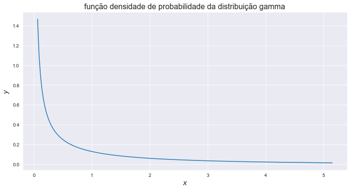

```python
plt.figure(figsize=(12,6))
plt.plot(gamma_x, gamma_pdf)
plt.xlabel(r'$x$', fontsize=14)
plt.ylabel(r'$y$', fontsize=14)
plt.title(r'função densidade de probabilidade da distribuição gamma',
          fontsize=16)
plt.show()
```

### Visualizando a distribuição da infectividade

- A seguir, alguns gráficos para visualizar a distribuição de $\rho_i$ na população.

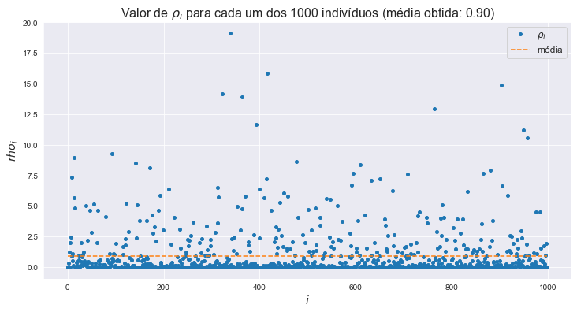

```python
plt.figure(figsize=(12,6))
plt.plot(rho, 'o', markersize=4, label=r'$\rho_i$')
plt.plot(range(num_pop), np.mean(rho)*np.ones(num_pop), '--', label='média')
plt.xlabel(r'$i$', fontsize=14)
plt.ylabel(r'$rho_i$', fontsize=14)
plt.legend(fontsize=12)
plt.title(r'Valor de $\rho_i$ para cada um dos' + f' {num_pop} indivíduos'
          + f' (média obtida: {np.mean(rho):.2f})', fontsize=16)
plt.show()
```

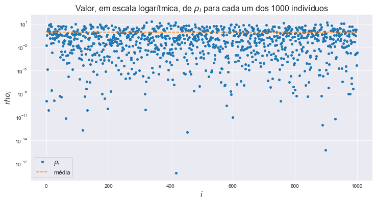

```python
plt.figure(figsize=(12,6))
plt.plot(rho, 'o', markersize=4, label=r'$\rho_i$')
plt.plot(range(num_pop), np.mean(rho)*np.ones(num_pop), '--', label='média')
plt.xlabel(r'$i$', fontsize=14)
plt.ylabel(r'$rho_i$', fontsize=14)
plt.yscale('log')
plt.legend(fontsize=12)
plt.title(r'Valor, em escala logarítmica, de $\rho_i$ para cada um dos'
          + f' {num_pop} indivíduos', fontsize=16)
plt.show()
```

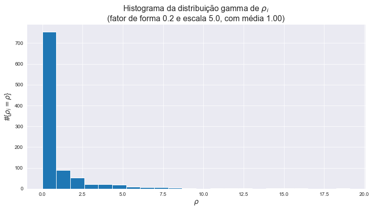

```python
plt.figure(figsize=(12,6))
plt.hist(rho, bins=22)
#plt.plot(range(num_pop), np.mean(rho)*np.ones(num_pop), '--', label='média')
plt.xlabel(r'$\rho$', fontsize=14)
plt.ylabel(r'#{$\rho_i=\rho$}', fontsize=14)
#plt.yscale('log')
plt.title(r'Histograma da distribuição gamma de $\rho_i$'
          + f'\n(fator de forma {rho_forma:.1f} e escala {rho_escala:.1f}, com média {rho_forma*rho_escala:.2f})',
          fontsize=16)
plt.show()
```

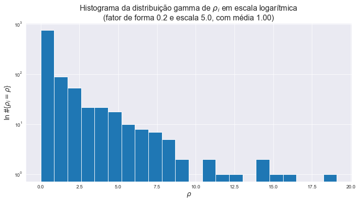

```python
plt.figure(figsize=(12,6))
plt.hist(rho, bins=22)
#plt.plot(range(num_pop), np.mean(rho)*np.ones(num_pop), '--', label='média')
plt.xlabel(r'$\rho$', fontsize=14)
plt.ylabel(r'$\ln$ #{$\rho_i=\rho$}', fontsize=14)
plt.yscale('log')
plt.title(r'Histograma da distribuição gamma de $\rho_i$ em escala logarítmica'
          + f'\n(fator de forma {rho_forma:.1f} e escala {rho_escala:.1f}, com média {rho_forma*rho_escala:.2f})',
          fontsize=16)
plt.show()
```

## Definição das idades

- Para a definição das idades, precisamos das informações da **pirâmide etária da cidade**.
- Essas pirâmides geralmente não são informadas ano-a-ano, mas em **grupos de idades**.
- Assim, **interpolamos** essa pirâmide em grupos para obter uma pirâmide **ano a ano**.
- Como o último grupo de idades é "aberto a direita", ou seja, não é de um ano a outro, mas, sim, a partir de um determinado ano, precisamos delimitar com uma **idade máxima**.

```python
def obtem_idades_fracoes(idades_grupos, idades_fracoes_grupos, idade_max=100, interp='linear'):
    '''Interpola a pirâmide populacional em grupos para uma pirâmide ano-a-ano.

    Recebe os grupos de idades e as frações correspondentes, assim como uma
    idade máxima, e interpola os valores para obter as frações ano a ano.

    A interpolação pode ser 'constante' por partes ou 'linear' por partes.
    '''

    # interpola/extrapola pirâmide populacional
    idades_fracoes = list()

    if interp == 'linear':
        for j in range(len(idades_grupos)-1):
            idades_fracoes += (idades_grupos[j+1] - idades_grupos[j]) \
                * [idades_fracoes_grupos[j]/(idades_grupos[j+1]-idades_grupos[j])]

        idades_fracoes += (idade_max - idades_grupos[-1]) \
            * [idades_fracoes_grupos[-1]/(idade_max-idades_grupos[-1])]
    elif interp == 'constante':
        for j in range(len(idades_grupos)-1):
            idades_fracoes += (idades_grupos[j+1] - idades_grupos[j]) \
                * [idades_fracoes_grupos[j]/(idades_grupos[j+1]-idades_grupos[j])]

        idades_fracoes += (idade_max - idades_grupos[-1]) \
            * [idades_fracoes_grupos[-1]/(idade_max-idades_grupos[-1])]
    else:
        raise ValueError("Argument 'interp' should be either 'linear' or 'constante'.")

    idades_fracoes = np.array(idades_fracoes)

    return idades_fracoes
```

```python
piramide_etaria_file \
    = os.path.join('..',
                   'input',
                   'dados_rio',
                   'piramide_etaria_MRJ.csv')

piramide_etaria = pd.read_csv(piramide_etaria_file)

piramide_etaria
```

|  | total | 0 | 1 | 2 | 3 | 4 | 5 | 6 | 7 | 8 | ... | 55 a 59 | 60 a 64 | 65 a 69 | 70 a 74 | 75 a 79 | 80 a 84 | 85 a 89 | 90 a 94 | 95 a 99 | 100 |
| --- | --- | --- | --- | --- | --- | --- | --- | --- | --- | --- | --- | --- | --- | --- | --- | --- | --- | --- | --- | --- | --- |
| 0 | 6320446 | 72828 | 72657 | 71632 | 72365 | 74550 | 77218 | 76536 | 77789 | 78054 | ... | 349675 | 279122 | 206203 | 170853 | 129430 | 90230 | 43786 | 16205 | 4259 | 763 |

1 rows × 42 columns

```python
idades_grupos = np.array([int(p[0:3])
                          for p in piramide_etaria.columns[1:]])

idades_fracoes_grupos \
    = piramide_etaria.iloc[0][1:].values/piramide_etaria.iloc[0][0]

idade_max = 110

idades_fracoes = obtem_idades_fracoes(
    idades_grupos, idades_fracoes_grupos, idade_max,
)
```

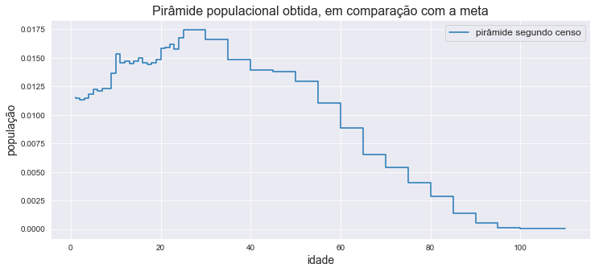

```python
plt.figure(figsize=(12,5))
#plt.hist(pop_idades, bins = list(range(idade_max+1)), color='tab:orange', label='pirâmide obtida')
plt.step(list(range(1, idade_max+1)), idades_fracoes, label='pirâmide segundo censo')
plt.xlabel('idade', fontsize=14)
plt.ylabel('população', fontsize=14)
plt.title(f'Pirâmide populacional obtida, em comparação com a meta', fontsize=16)
plt.legend(fontsize=12)
plt.show()
```

```python
def gera_idades(num_pop, num_tam_res, res_individuos, idades_fracoes):

    # separa as residências por tamanho
    res = (num_tam_res+1)*[[]]
    for j in range(1,num_tam_res+1):
        # seleciona residências com j indivíduos (res[0]=[])
        res[j] = [r for r in res_individuos if len(r) == j]
    # separa as residências com um adulto e um menor:
    res_2b = random.sample(res[2], k=int(0.1*len(res[2])))
    # separa as residências com dois adultos:
    res_2a = [r for r in res[2] if r not in res_2b]
    # agrega as residências com três ou mais indivíduos:
    res_3mais = []
    for res_k in res[3:]:
        res_3mais += res_k

    # separa a pirâmide populacional
    idades = list(range(len(idades_fracoes)))

    distrib_idades_adultos = num_pop*idades_fracoes
    distrib_idades_adultos[:20] = 0

    distrib_idades_menores = num_pop*idades_fracoes
    distrib_idades_menores[20:] = 0

    # inicializa lista de idades
    pop_idades = np.zeros(num_pop).astype(int)

    # define a idade dos adultos morando sozinhos
    ind_idades = random.choices(idades, distrib_idades_adultos, k=len(res[1]))
    for j in range(len(res[1])):
        pop_idades[res[1][j]] = ind_idades[j]
        distrib_idades_adultos[ind_idades[j]] -= 1

    # define a idade do único adulto em residências com um adulto e um menor
    ind_idades = random.choices(idades, distrib_idades_adultos, k=len(res_2b))
    for j in range(len(res_2b)):
        pop_idades[res_2b[j][0]] = ind_idades[j]
        distrib_idades_adultos[ind_idades[j]] -= 1

    # define a idade de dois adultos nas outras residências com dois
    # indivíduos
    len_res_2a = len(res_2a)
    ind_idades = random.choices(idades, distrib_idades_adultos,
                                k=2*len_res_2a)
    for j in range(len_res_2a):
        pop_idades[res_2a[j][0]] = ind_idades[j]
        pop_idades[res_2a[j][1]] = ind_idades[len_res_2a + j]
        distrib_idades_adultos[ind_idades[j]] -= 1
        distrib_idades_adultos[ind_idades[len_res_2a + j]] -= 1

    # define a idade de dois adultos nas residências com três ou mais
    # indivíduos
    len_res_3mais = len(res_3mais)
    ind_idades = random.choices(idades, distrib_idades_adultos,
                                k=2*len_res_3mais)
    for j in range(len_res_3mais):
        pop_idades[res_3mais[j][0]] = ind_idades[j]
        pop_idades[res_3mais[j][1]] = ind_idades[len_res_3mais + j]
        distrib_idades_adultos[ind_idades[j]] -= 1
        distrib_idades_adultos[ind_idades[len_res_3mais + j]] -= 1

    # define a idade dos menores de idade em residências com um adulto
    # e um menor
    len_res_2b = len(res_2b)
    ind_idades = random.choices(idades, distrib_idades_menores, k=len_res_2b)
    for j in range(len_res_2b):
        pop_idades[res_2b[j][1]] = ind_idades[j]
        distrib_idades_menores[ind_idades[j]] -= 1

    # calcula a distribuição restante de idades
    distrib_idades_left = np.array(
        [distrib_idades_menores[j] + distrib_idades_adultos[j]
        for j in range(len(idades_fracoes))]
        )

    # define a idade do restante dos invidívuos em residências de três
    # ou mais indivíduos
    for k in range(3,num_tam_res+1):
        ind_idades = random.choices(idades, distrib_idades_left,
                                    k=(k-2)*len(res[k]))
        for j in range(len(res[k])):
            for l in range(2, k):
                pop_idades[res[k][j][l]] = ind_idades[(l-2)*len(res[k]) + j]
                distrib_idades_left[ind_idades[(l-2)*len(res[k]) + j]] -= 1

    return pop_idades
```

```python
        self.pop_idades = gera_idades(
            self.num_pop, num_tam_res,
            self.res_individuos, self.idades_fracoes)
```

## Referências

- [DeGroot MH, Schervish MJ (2012), Probability and Statistics, 4th edition, Pearson Education, Inc.](https://www.pearson.com/us/higher-education/program/De-Groot-Probability-and-Statistics-4th-Edition/PGM146802.html).